# Untitled

Sean Fahey

2023-04-12

# In Class work

Principal Coordinates Analysis (PCoA)

Like PCA, but preserves distances between plots/individuals/sites. Basically it’s a PCA but using non-euclidean distances.

### plant species data set in Bryce canyon

```r
veg = read.csv("bryceveg.txt", header=TRUE, sep=' ')
sites = read.csv("brycesite.txt", header=TRUE, sep=' ', row.names=1)
```

Each plant species gets a coverage score from 0 to 6. 0 is not present, 0.5 is trace presence, 6 is abundant. Each row is a site in Bryce canyon that was measured.

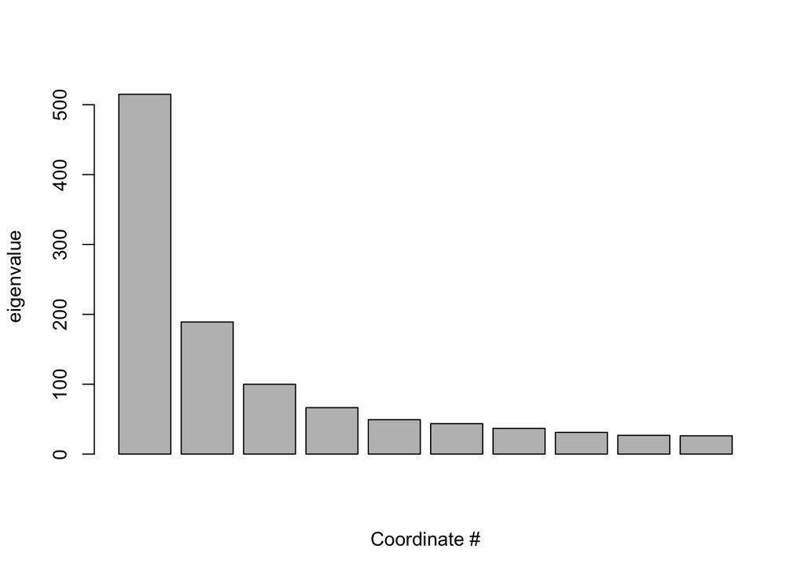

```r
# get the distance matrix
dis.euc = dist(veg, 'euclidian')

# do a PCoA on those distances.
pco.euc = cmdscale(dis.euc, eig=TRUE)

# another way to do a quick screeplot
barplot(pco.euc$eig[1:10], xlab="Coordinate #", ylab="eigenvalue")
```

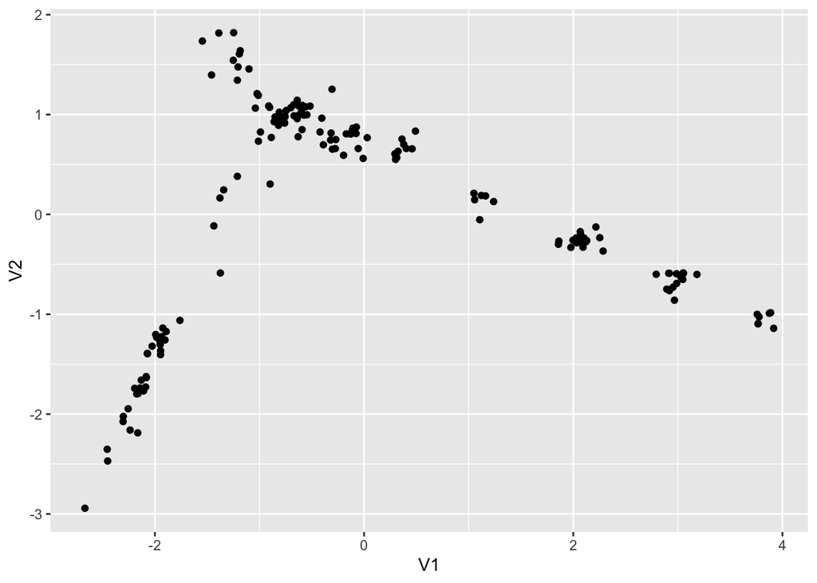

```r
autoplot(pco.euc)
```

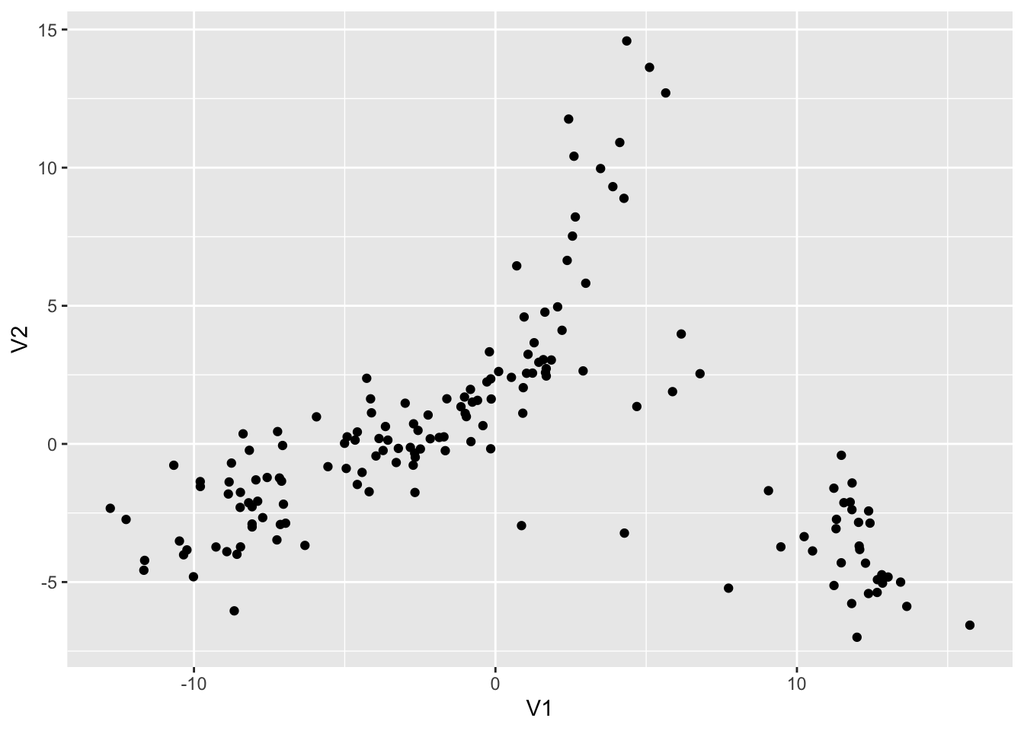

```r
# get the Manhattan distance matrix
dis.man = dist(veg, 'manhattan')

# do a PCoA on those distances.
pco.man = cmdscale(dis.man, eig=TRUE)

autoplot(pco.man)
```

Plot looks different now. More spread. This uses sum of distances on x and y instead of Pythagorean theorem.

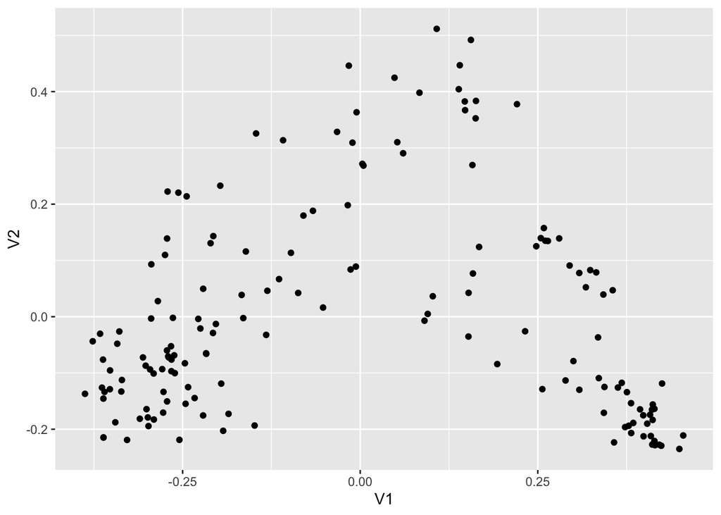

```r
# this converts everything to 0 or 1, and calculates binary distance
dis.bin = dist(veg, 'binary')

# do a PCoA on those distances.
pco.bin = cmdscale(dis.bin, eig=TRUE)

autoplot(pco.bin)
```

Even more spread now.

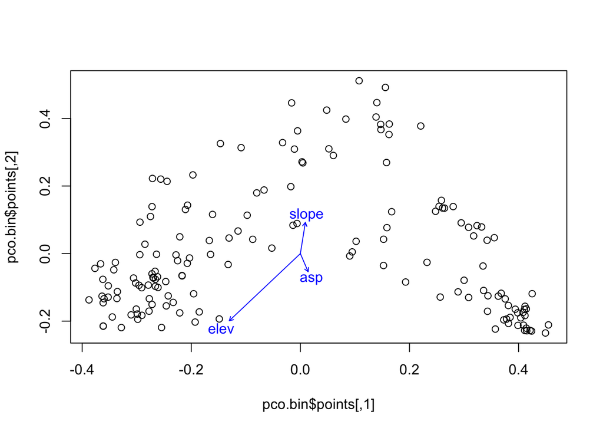

```r
ef = envfit(pco.bin, sites[, c('asp', 'elev', 'slope')])

plot(pco.bin$points)
plot(ef)
```

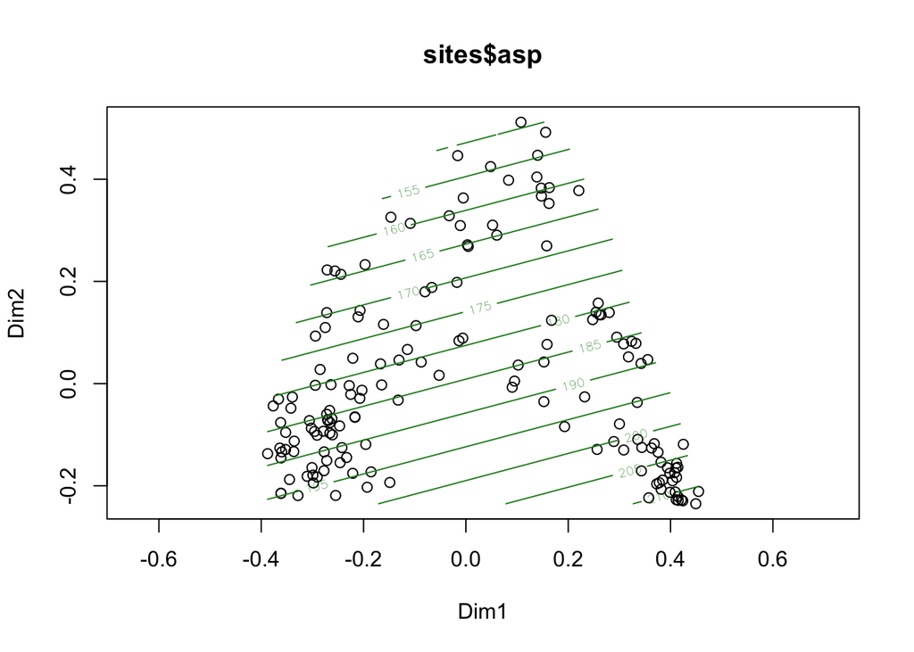

```
##
## Family: gaussian
## Link function: identity
##
## Formula:
## y ~ s(x1, x2, k = 10, bs = "tp", fx = FALSE)
##
## Estimated degrees of freedom:
## 1.42  total = 2.42
##
## REML score: 968.2557
```

```r
ordisurf(pco.bin, sites$asp, col='forestgreen')
```

### Ant dataset

```r
ant = read.csv('AntPresenceAbsence.csv', header=TRUE)
```

using vegdist() from vegan package instead of dist(), which can handle bray-curtis

Leave out sites (column 1) because it’s really just the index name.

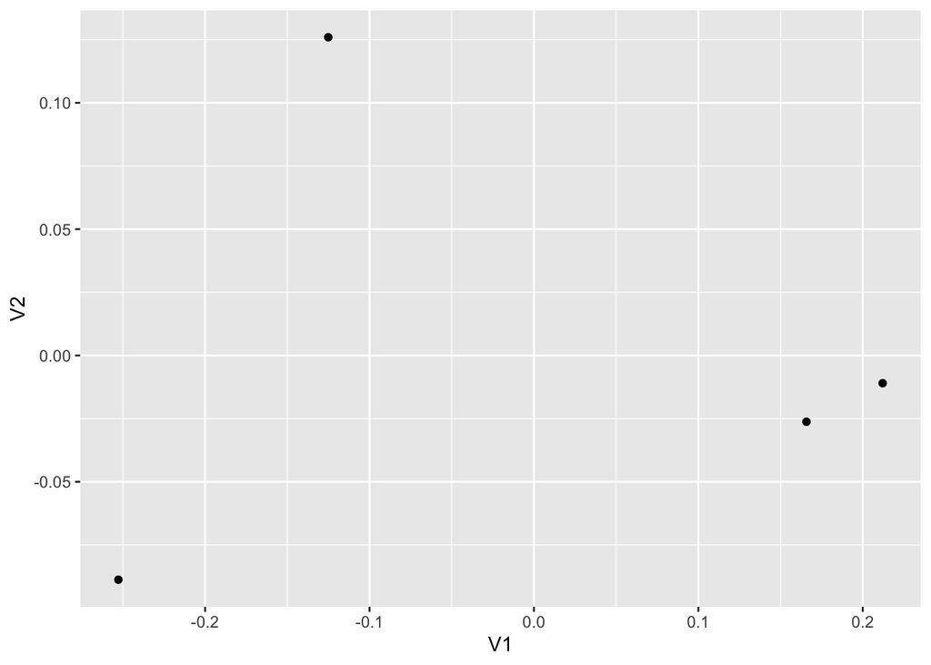

```r
dis.bc = vegdist(ant[,-1], method='bray')

pco.bc = cmdscale(dis.bc, eig=TRUE)

autoplot(pco.bc)
```

Some notes:

There’s no significance we can establish from this. Just shows where the data falls in the plot. Basically, no p-values.

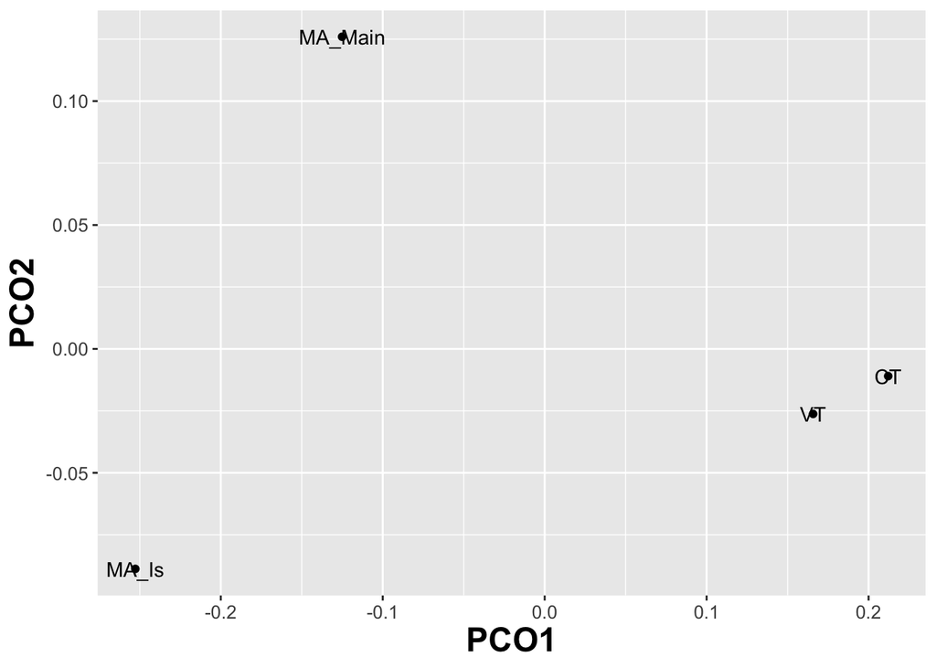

```r
dimnames(pco.bc$points)[[1]] = ant$Site

autoplot(
  pco.bc,
  label=TRUE,
  xlab="PCO1",
  ylab="PCO2"
  ) +
  theme(
    axis.text=element_text(size=10),
    axis.title=element_text(size=18, face='bold')
  )
```

final presentation notes:

multivariate analyses Need to calculate some distances between stuff. Do soemthing like a PCoA/PCA. Intro the data Walk through methods Explain the patterns I see, results, etc. Professional looking slides. Just a couple references in slides is fine. 10 minute, conference style. Speak professionally about the data.

# Homework

1. Visualize distribution for each compound. Should I log transform the data? hist for each of the 33 columns
2. Do a PCA (prcomp)
3. Show the relationship between compounds using a biplot
4. Find the most important compounds with the help of a contribution plot (fviz_contrib), subset the data and re-run PCA with only those compounds that fall above the red line on the contribution plot.
5. Evaluate their contribution to PC1 and PC2 using a biplot (fviz_pca_biplot). Color the two maturity classes on the biplot and include a convex hull around the two classes of dolphins. Suppress the arrows for the variables (compounds), only show the variable locations and text labels.
6. Based on the final biplot, are different compounds associated more with immature than mature dolphins?

```r
blubber = read.csv("Trego2018.csv", header=TRUE)
```

Visualize distribution for each compound. Should I log transform the data?

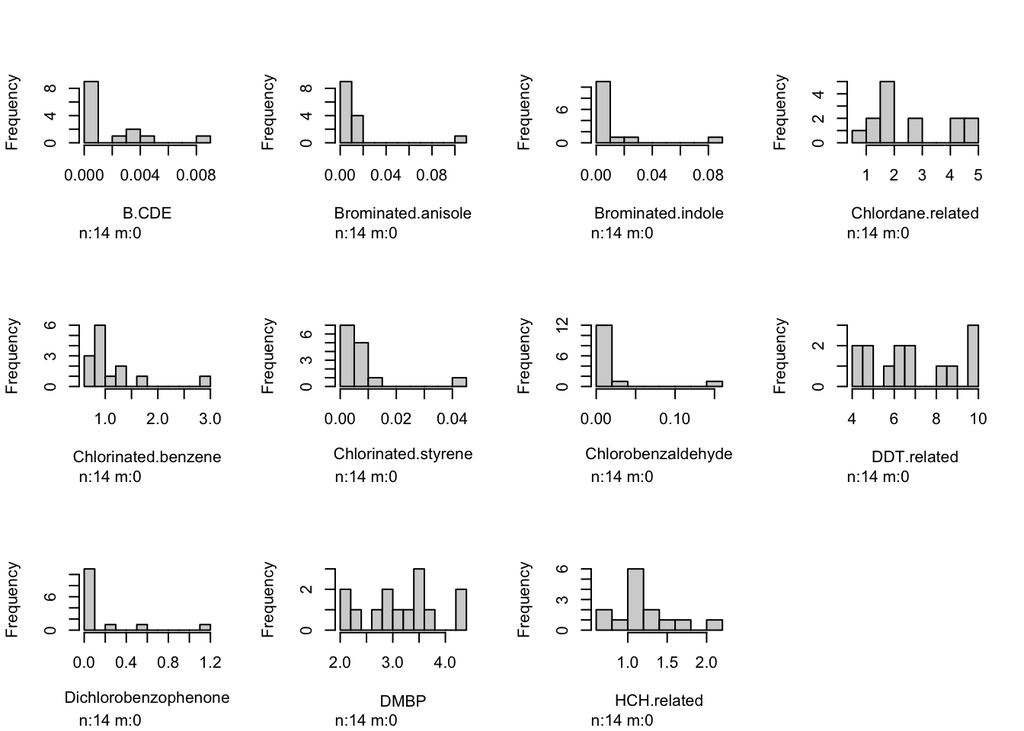

```r
hist.data.frame(blubber[3:13], nclass=10)
```

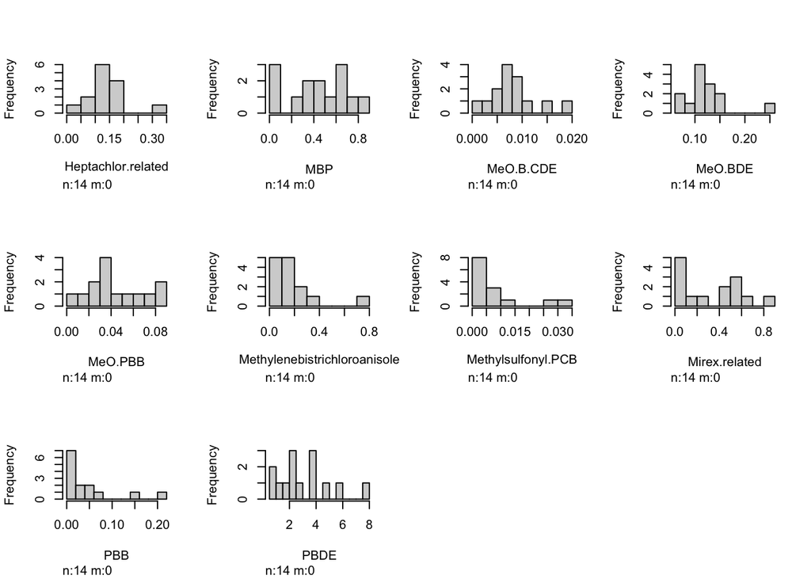

```r
hist.data.frame(blubber[14:23], nclass=10)
```

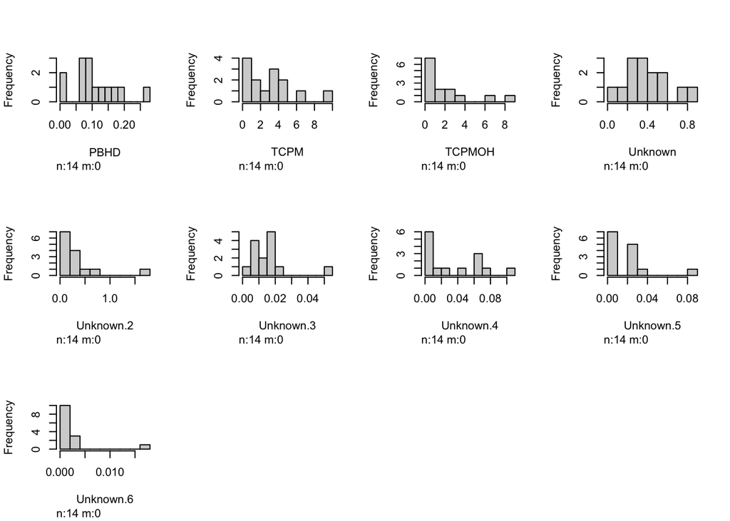

```r
hist.data.frame(blubber[24:33], nclass=10)
```

Looks like some of these should be log transformed: - B.CDE - Brominated.anisole - Brominated.indole - Methylsulfonyl.PCB - PBB - TCPMOH - Unknown.2 - Unknown.6

Apply some logs and check for improvement.

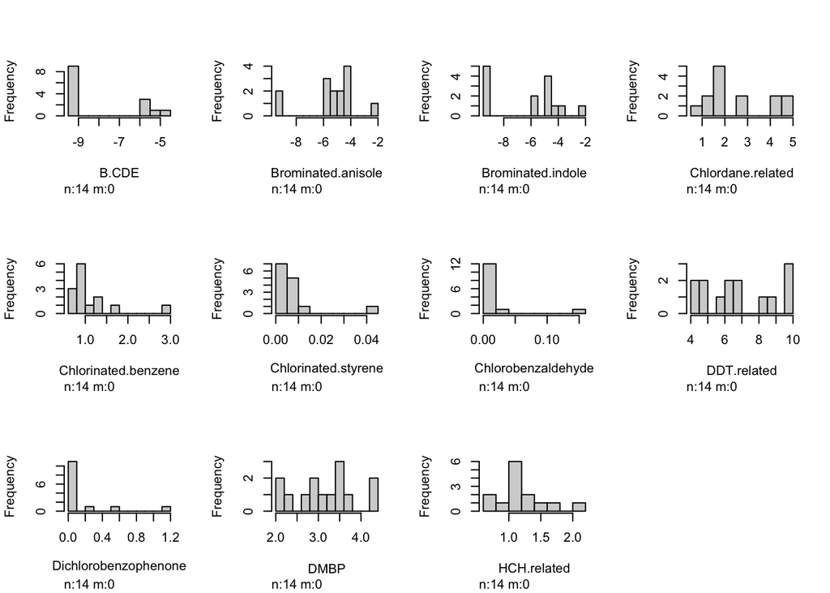

```r
blubber[, c(3:35)] = blubber[, c(3:35)] + 0.0001

blubber$B.CDE = log(blubber$B.CDE)
blubber$Brominated.anisole = log(blubber$Brominated.anisole)
blubber$Brominated.indole = log(blubber$Brominated.indole)
blubber$Methylsulfonyl.PCB = log(blubber$Methylsulfonyl.PCB)
blubber$PBB = log(blubber$PBB)
blubber$TCPMOH = log(blubber$TCPMOH)
blubber$Unknown.2 = log(blubber$Unknown.2)
blubber$Unknown.6 = log(blubber$Unknown.6)

hist.data.frame(blubber[3:13], nclass=10)
```

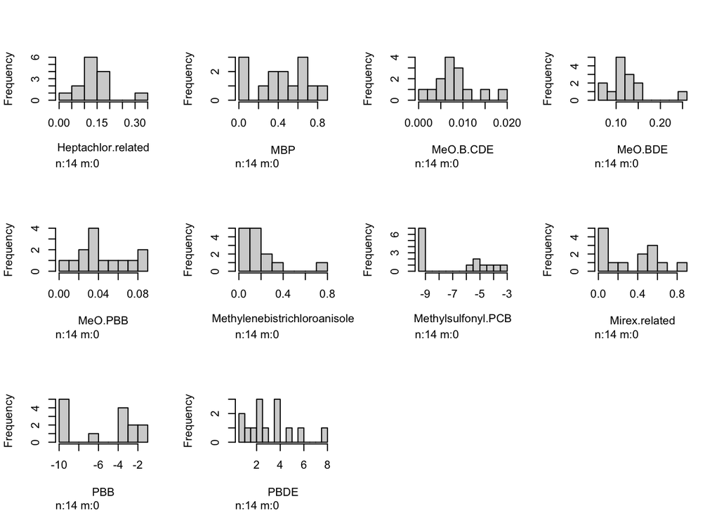

```r
hist.data.frame(blubber[14:23], nclass=10)
```

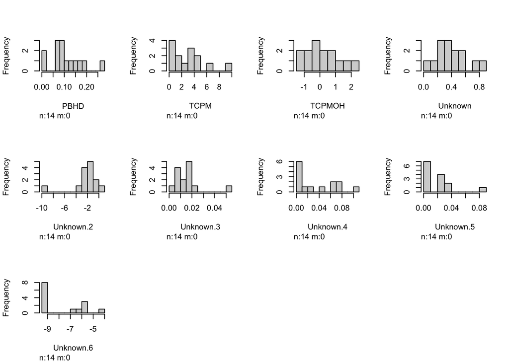

```r
hist.data.frame(blubber[24:33], nclass=10)
```

Added 0.0001 to all columns to prevent log(0) from breaking.

Do a PCA (prcomp)

```r
pca.blubber = prcomp(blubber[,c(3:35)], scale=TRUE)
```

Show the relationship between compounds using a biplot

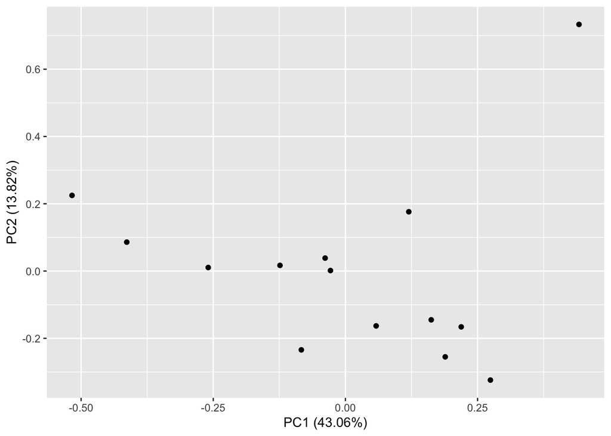

```r
autoplot(pca.blubber)
```

I can sort of see some groupings, with a few points far from the rest.

Find the most important compounds with the help of a contribution plot (fviz_contrib)

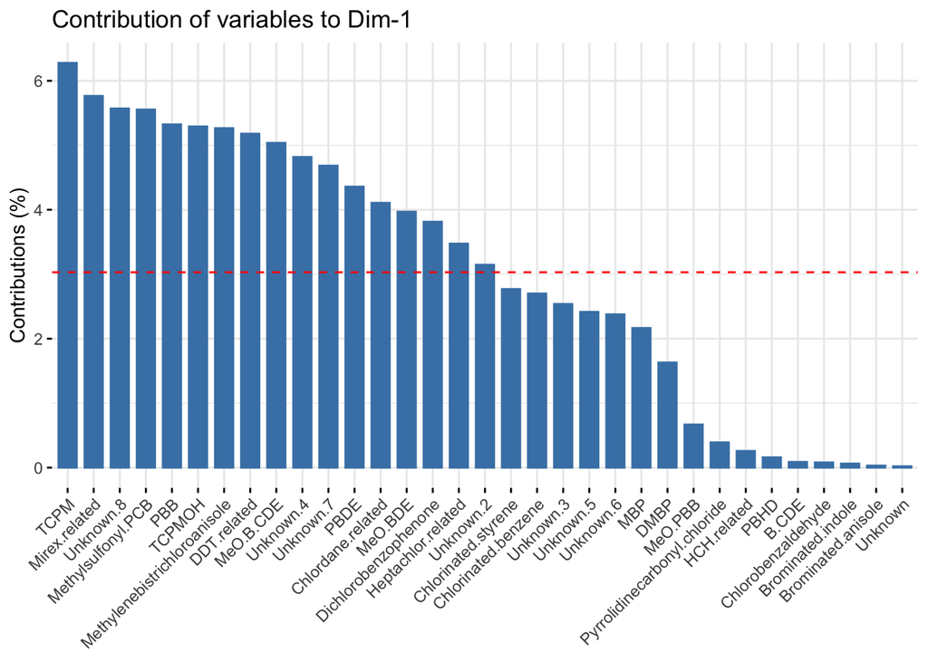

```r
fviz_contrib(pca.blubber, choice="var", axes = 1)
```

More than half of the data is above the cutoff.

Subset the data and re-run PCA with only those compounds that fall above the red line on the contribution plot.

```r
blubber.good = blubber[,c(
"Chlordane.related",
"DDT.related",
"Dichlorobenzophenone",
"Heptachlor.related",
"MeO.B.CDE",
"MeO.BDE",
"Methylenebistrichloroanisole",
"Methylsulfonyl.PCB",
"Mirex.related",
"PBB",
"PBDE",
"TCPM",
"TCPMOH",
"Unknown.2",
"Unknown.4",
"Unknown.7"
)]

pca.blubber.good = prcomp(blubber.good, scale=TRUE)
```

Evaluate their contribution to PC1 and PC2 using a biplot (fviz_pca_biplot). Color the two maturity classes on the biplot and include a convex hull around the two classes of dolphins. Suppress the arrows for the variables (compounds), only show the variable locations and text labels.

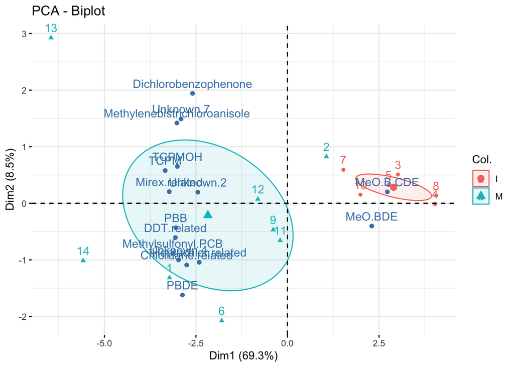

```r
fviz_pca_biplot(
  pca.blubber.good,
  axes = c(1, 2),
  geom = c("point", "text"),
  geom.var = c("point", "text"), # suppressed arrows
  col.ind = blubber$Maturity,
  addEllipses = TRUE,
  ellipse.type = 'confidence'
  )
```

Question 6: Based on the final biplot, are different compounds associated more with immature than mature dolphins?

Answer: It looks like **MeO.B.CDE** and **MeO.BDE** are far more associated with immature dolphins than mature dolphins, at least as far as the first 2 principal components. The rest of the mass spec data colelcted is associated more closely with mature dolphins.